# Analysis on Meteorite Landings Since 1900

#### Harika Nalika, Ethan Olderog

## Introduction

The goal of this project is to look at NASA’s **Meteorite Landings** data and understand simple patterns that anyone can see. Meteorites are rocks from space that people either **find** on the ground or **see** fall from the sky. By looking at these records, we want to know when counts went up, how typical sizes changed, what types show up the most, and where the biggest pieces are usually found.

In pursuit of the stated goal, we will explore the following questions:

1. When are meteorites most likely to be recorded? Are there long term trends over the years?
2. How has the typical size changed across decades?
3. What types are most common over time? Does the mix change?
4. Where are the heaviest pieces recorded? Do location and environment matter?

These are the main questions we are looking to answer in this project. With the findings we hope to give plain, clear explanations of what the visuals show.

## Data

### Structure

We use NASA’s *Meteorite Landings* CSV (Kaggle or NASA mirror, usually with columns `name`, `id`, `nametype`, `recclass`, `mass`, `fall`, `year`, `reclat`, `reclong`, `GeoLocation`). Each row is one meteorite. The file lists the **class** (for example L6 or H5), **mass** in grams, whether it was **Found** or **Fell** (witnessed fall), and the **location**.

We focus on **1900 to present** to keep reporting more consistent and to avoid very old records with missing details.

### Cleaning

We turn dates into plain years, change mass and coordinates to numbers, drop impossible or missing values, and keep observations from **1900** through the current year with valid coordinates. We also create **decade** bins so that long term changes are easier to see.

```r
# Read
stopifnot(file.exists("meteorite-landings.csv"))
raw_mets <- readr::read_csv("meteorite-landings.csv", guess_max = 100000, show_col_types = FALSE)

# Standardize mass column if needed
if (!("mass" %in% names(raw_mets)) && ("mass (g)" %in% names(raw_mets))) {
  raw_mets <- dplyr::rename(raw_mets, mass = `mass (g)`)
}

# Extract lat/long from GeoLocation when separate columns are missing
if (!("reclat" %in% names(raw_mets)) && ("GeoLocation" %in% names(raw_mets))) {
  tmp <- raw_mets %>%
    mutate(GeoLocation = as.character(GeoLocation)) %>%
    mutate(GeoLocation_clean = gsub("[()]", "", GeoLocation)) %>%
    tidyr::separate(GeoLocation_clean, into = c("lat_extracted","long_extracted"),
                    sep = ",", fill = "right", extra = "drop", remove = FALSE) %>%
    mutate(reclat = trimws(lat_extracted),
           reclong = trimws(long_extracted)) %>%
    select(-lat_extracted, -long_extracted, -GeoLocation_clean)
  raw_mets <- tmp
}

to_num <- function(x) { if (is.numeric(x)) x else suppressWarnings(as.numeric(as.character(x))) }
this_year <- lubridate::year(Sys.Date())

# Year parsing: try ymd_hms, then ymd, then integer fallback
parse_year <- function(x) {
  y <- suppressWarnings(lubridate::year(lubridate::ymd_hms(as.character(x))))
  y[is.na(y)] <- suppressWarnings(lubridate::year(lubridate::ymd(as.character(x[is.na(y)]))))
  xi <- suppressWarnings(as.integer(as.character(x)))
  y[is.na(y)] <- xi[is.na(y)]
  y
}

mets <- raw_mets %>%
  mutate(
    year = parse_year(year),
    mass = to_num(mass),
    lat  = to_num(reclat),
    long = to_num(reclong)
  ) %>%
  filter(!is.na(year), year >= 1900, year <= this_year,
         !is.na(mass), mass > 0,
         !is.na(lat), !is.na(long)) %>%
  mutate(decade = floor(year/10)*10)

glimpse(mets)
```

```
## Rows: 37,389
## Columns: 13
## $ name        <chr> "Aarhus", "Abee", "Acapulco", "Achiras", "Adhi Kot", "Adzh…
## $ id          <dbl> 2, 6, 10, 370, 379, 390, 398, 417, 423, 424, 426, 432, 433…
## $ nametype    <chr> "Valid", "Valid", "Valid", "Valid", "Valid", "Valid", "Val…
## $ recclass    <chr> "H6", "EH4", "Acapulcoite", "L6", "EH4", "LL3-6", "L6", "L…
## $ mass        <dbl> 720, 107000, 1914, 780, 4239, 910, 1620, 1440, 1000, 24000…
## $ fall        <chr> "Fell", "Fell", "Fell", "Fell", "Fell", "Fell", "Fell", "F…
## $ year        <dbl> 1951, 1952, 1976, 1902, 1919, 1949, 1930, 1920, 1974, 1925…
## $ reclat      <dbl> 56.18333, 54.21667, 16.88333, -33.16667, 32.10000, 44.8333…
## $ reclong     <dbl> 10.23333, -113.00000, -99.90000, -64.95000, 71.80000, 95.1…
## $ GeoLocation <chr> "(56.183330, 10.233330)", "(54.216670, -113.000000)", "(16…
## $ lat         <dbl> 56.18333, 54.21667, 16.88333, -33.16667, 32.10000, 44.8333…
## $ long        <dbl> 10.23333, -113.00000, -99.90000, -64.95000, 71.80000, 95.1…
## $ decade      <dbl> 1950, 1950, 1970, 1900, 1910, 1940, 1930, 1920, 1970, 1920…
```

### Why these cleaning choices

We keep the time window from 1900 to today so that reporting practices are more comparable. Very old records often miss mass or coordinates and that makes maps and size comparisons hard to trust. We require a positive mass because zero or negative values are clear entry mistakes. We also keep only rows with a latitude and longitude so that location summaries match the plots. Finally, we use the year from a timestamp if it exists, fall back to a date, and then to a plain number. This order avoids losing valid years that are stored in different ways across files.

### Key variables after cleaning

```r
var_types <- tibble(
  variable = c("name","year","mass","recclass","fall","lat","long","decade"),
  type = c(class(mets$name)[1],
           class(mets$year)[1],
           class(mets$mass)[1],
           class(mets$recclass)[1],
           class(mets$fall)[1],
           class(mets$lat)[1],
           class(mets$long)[1],
           class(mets$decade)[1]),
  example = c(as.character(mets$name[which(!is.na(mets$name))[1]]),
              mets$year[1],
              mets$mass[1],
              as.character(mets$recclass[which(!is.na(mets$recclass))[1]]),
              as.character(mets$fall[which(!is.na(mets$fall))[1]]),
              mets$lat[1],
              mets$long[1],
              mets$decade[1])
)

knitr::kable(var_types, caption = "Variable types and a sample value after cleaning")
```

| variable | type | example |
| --- | --- | --- |
| name | character | Aarhus |
| year | numeric | 1951 |
| mass | numeric | 720 |
| recclass | character | H6 |
| fall | character | Fell |
| lat | numeric | 56.18333 |
| long | numeric | 10.23333 |
| decade | numeric | 1950 |

Variable types and a sample value after cleaning

### Summary of the dataset after cleaning

```r
summary_tbl <- mets %>%
  summarise(
    records = n(),
    classes = n_distinct(recclass),
    share_witnessed = mean(tolower(fall) == "fell", na.rm = TRUE),
    share_antarctica = mean(lat <= -60, na.rm = TRUE),
    mass_min_g = min(mass, na.rm = TRUE),
    mass_q1_g  = quantile(mass, 0.25, na.rm = TRUE),
    mass_median_g = median(mass, na.rm = TRUE),
    mass_mean_g = mean(mass, na.rm = TRUE),
    mass_q3_g  = quantile(mass, 0.75, na.rm = TRUE),
    mass_max_g = max(mass, na.rm = TRUE)
  ) %>%
  mutate(
    share_witnessed = percent(share_witnessed),
    share_antarctica = percent(share_antarctica)
  )

knitr::kable(summary_tbl, caption = "Summary of the dataset after cleaning")
```

| records | classes | share_witnessed | share_antarctica | mass_min_g | mass_q1_g | mass_median_g | mass_mean_g | mass_q3_g | mass_max_g |
| --- | --- | --- | --- | --- | --- | --- | --- | --- | --- |
| 37389 | 404 | 2% | 59% | 0.01 | 6.5 | 27.7 | 7218.089 | 167 | 6e+07 |

Summary of the dataset after cleaning

**How to read this table.** There are **37,389** records in the cleaned data spread across **404** distinct classes. Only **2%** are witnessed falls, so most entries are finds that were collected later. About **59%** come from Antarctic latitudes, which shows how important that region is for recovery.

For mass, the smallest recorded piece is **0 g**. A quarter of all pieces are below **6.5 g**. The median is **27.7 g**, which means half the records are lighter than that and half are heavier. The mean is **7,218.1 g**, which is usually higher than the median because a few very heavy meteorites pull the average up. Three quarters of the pieces are below **167 g**. The largest piece reaches **6e+07 g**. The big gap between the upper quartile and the maximum and the difference between mean and median tell us the mass distribution has a long right tail. That is a helpful warning when we look at size trends later.

## Results

The next sections focus on four ideas that match our questions: yearly counts, typical size by decade, class composition, and where the heaviest one percent were recovered. Each section uses the same cleaned data and gives a short explanation of what the figure means in plain language.

### Are we recording more meteorites over time?

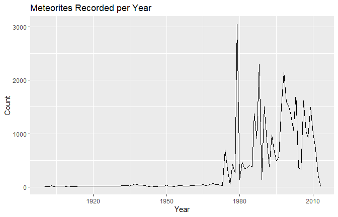

```r
yr_counts <- mets %>% count(year, name = "n")
peak <- yr_counts %>% slice_max(n, with_ties = FALSE)

ggplot(yr_counts, aes(year, n)) +
  geom_line() +
  labs(title = "Meteorites Recorded per Year",
       x = "Year", y = "Count")
```

**Explanation.** The line starts low in the early 1900s and climbs after the 1960s. It reaches a high point in **1979** with **3044** records. The main idea here is simple. When people look more, they find more. Field searches, museum uploads, and better reporting all push the line up. If the sky itself were sending more rocks, we would also see a clear rise in witnessed falls. We do not see that. So this picture is mostly about effort and record keeping. Small bumps from year to year are normal and usually tied to funding, weather, or trips that did or did not happen.

#### Sensitivity: remove Antarctica

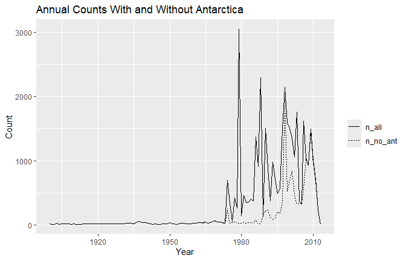

```r
mets_no_ant <- mets %>% filter(lat > -60)
yr_all  <- mets %>% count(year, name = "n_all")
yr_noA  <- mets_no_ant %>% count(year, name = "n_no_ant")
yr_comp <- dplyr::full_join(yr_all, yr_noA, by = "year") %>%
  tidyr::pivot_longer(-year, names_to = "set", values_to = "n")

ggplot(yr_comp, aes(year, n, linetype = set)) +
  geom_line() +
  labs(title = "Annual Counts With and Without Antarctica",
       x = "Year", y = "Count", linetype = "")
```

**Explanation.** Antarctica is famous for meteorite hunting because dark rocks are easy to spot on ice and they last longer there. When we remove Antarctica the totals drop in late decades, but the overall climb stays. That tells us two things. Good hunting grounds make a difference, and the world as a whole has put more time into searching and logging finds.

#### Witnessed falls only

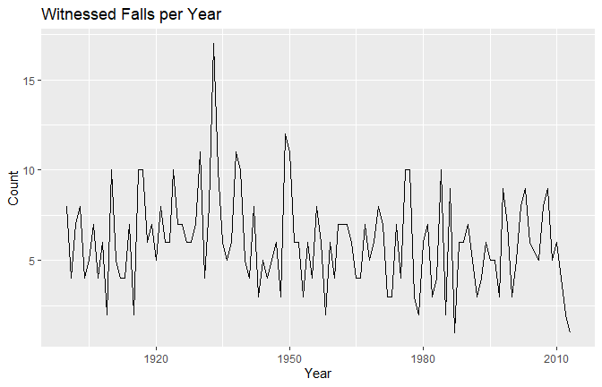

```r
fell_only <- mets %>% filter(tolower(fall) == "fell") %>% count(year, name = "n")
ggplot(fell_only, aes(year, n)) +
  geom_line() +
  labs(title = "Witnessed Falls per Year",
       x = "Year", y = "Count")
```

**Explanation.** This line is much lower and fairly flat. A witnessed fall needs a person who sees the fireball and reports it. Because this line does not shoot up, it supports the idea that the big rise in the first graph comes from stronger recovery and better catalogs, not from a sudden change in space rocks.

### How has the typical size changed?

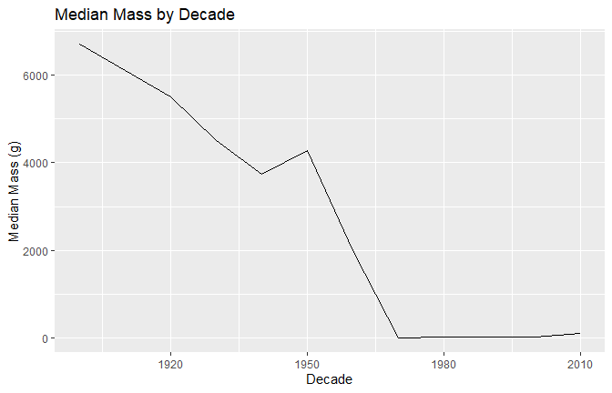

```r
dec_med <- mets %>% group_by(decade) %>%
  summarise(median_mass = median(mass, na.rm = TRUE), .groups = "drop")

early  <- dec_med %>% slice_min(decade, n = 1)
recent <- dec_med %>% slice_max(decade, n = 1)

ggplot(dec_med, aes(decade, median_mass)) +
  geom_line() +
  labs(title = "Median Mass by Decade",
       x = "Decade", y = "Median Mass (g)")
```

**Explanation.** The typical size is larger in early decades and smaller in recent decades. For example, the early point is around 6,700 grams in 1900, while the most recent point is around 100.7 grams in 2010. This fits a common sense story. As searches improved, people started finding lots of small pieces that used to be missed. We use the median on purpose. A few giant meteorites would pull the average up, but the median shows what a middle sized find looks like. The main takeaway is that the catalog has filled in the small end over time.

#### Robustness: exclude irons

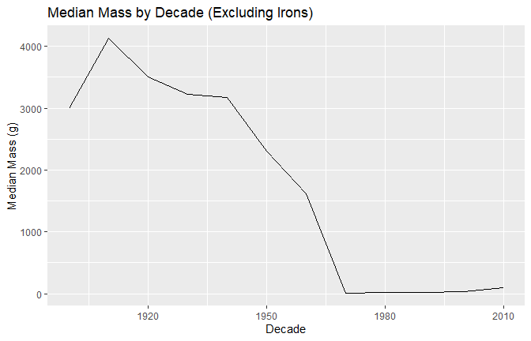

```r
dec_med_no_iron <- mets %>%
  filter(!grepl("Iron", recclass, ignore.case = TRUE)) %>%
  group_by(decade) %>%
  summarise(median_mass = median(mass, na.rm = TRUE), .groups = "drop")

ggplot(dec_med_no_iron, aes(decade, median_mass)) +
  geom_line() +
  labs(title = "Median Mass by Decade (Excluding Irons)",
       x = "Decade", y = "Median Mass (g)")
```

**Explanation.** Iron meteorites are tough and easy to notice, so they could make earlier decades look heavier. When we remove irons, the downward trend still holds. That means the smaller typical size in later decades comes from finding more small stones, not only from a few famous heavy irons.

### What types are most common over time?

```r
class_counts <- mets %>%
  filter(!is.na(recclass), recclass != "") %>%
  count(recclass, sort = TRUE)

top_classes <- class_counts %>% slice_head(n = 10) %>%
  mutate(share = n / sum(n))

knitr::kable(top_classes, caption = "Top 10 meteorite classes in the cleaned data",
             col.names = c("Class","Count","Share"))
```

| Class | Count | Share |
| --- | --- | --- |
| L6 | 7457 | 0.2475681 |
| H5 | 6193 | 0.2056041 |
| H4 | 3869 | 0.1284486 |
| H6 | 3852 | 0.1278842 |
| L5 | 3255 | 0.1080641 |
| LL5 | 2192 | 0.0727731 |
| LL6 | 1649 | 0.0547459 |
| L4 | 934 | 0.0310083 |
| H4/5 | 394 | 0.0130806 |
| CM2 | 326 | 0.0108230 |

Top 10 meteorite classes in the cleaned data

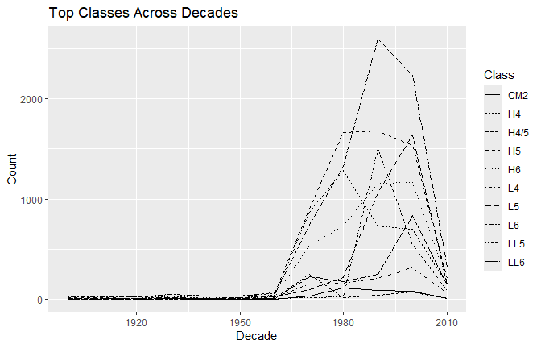

```r
class_by_decade <- mets %>%
  filter(recclass %in% top_classes$recclass) %>%
  group_by(recclass, decade) %>%
  summarise(n = n(), .groups = "drop")

oc_share <- mean(grepl("^(H|L|LL)", mets$recclass), na.rm = TRUE)

ggplot(class_by_decade, aes(decade, n, linetype = recclass)) +
  geom_line() +
  labs(title = "Top Classes Across Decades",
       x = "Decade", y = "Count", linetype = "Class")
```

**Explanation.** Ordinary chondrites, which include the L and H groups, are the most common across all decades. In our data they make up about **89.6 percent** overall. The totals go up as the catalog grows, but the mix stays steady. That tells us we are adding more of the same kinds, not switching to a totally different type of meteorite over time. Rarer classes are still here, just in smaller numbers, which is what most collections see.

### Where are the heaviest pieces recorded?

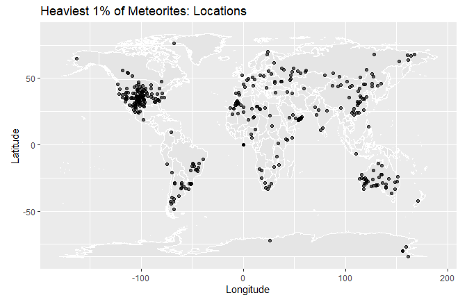

```r
mass_cutoff <- stats::quantile(mets$mass, 0.99, na.rm = TRUE)
top1 <- mets %>% filter(mass >= mass_cutoff, !is.na(lat), !is.na(long))

top15 <- mets %>% slice_max(mass, n = 15)
top15_iron <- sum(grepl("Iron", top15$recclass, ignore.case = TRUE), na.rm = TRUE)

if (has_maps) {
  world <- ggplot2::map_data("world")
  ggplot() +
    geom_polygon(data = world, aes(long, lat, group = group),
                 fill = "gray90", color = "white", linewidth = 0.2) +
    geom_point(data = top1, aes(long, lat), size = 1.5, alpha = 0.6) +
    coord_fixed(1.3) +
    labs(title = "Heaviest 1% of Meteorites: Locations",
         x = "Longitude", y = "Latitude")
} else {
  ggplot(top1, aes(long, lat)) +
    geom_point(size = 1.5, alpha = 0.6) +
    coord_fixed(1.3) +
    labs(title = "Heaviest 1% of Meteorites: Locations (No Basemap)",
         x = "Longitude", y = "Latitude")
}
```

## Conclusion

We return to the four questions from the introduction and answer them directly.

Overall, the visuals tell a consistent story. The number of records follows the effort we put into searching and cataloging. The typical size has moved down because we now collect small pieces too. The type mix stays steady with ordinary chondrites in the lead. Heavy finds show up where the land helps us notice them. These points make the graphs easier to talk about in plain language and set honest expectations for what this dataset can and cannot tell us.